# Common Mistakes

ECON 526/593E

I wanted to take some time to write up some common mistakes, oddities, quirks, etc. I see in the HWs so people can take note.

1. Please use `echo = TRUE` in your HWs so I can see your code. It is helpful for me to understand what you were thinking. Commenting your code is also helpful when we get into more complicated things.
2. In R, there are (basically) 3 ways to assign values to variables/objects. One can use `=`, `<-` or `->`. There are some subtle differences when using these and it is valueable to know these. In summary, one should use `<-` (or `->`) when assigning a value to an object in a "global scope" and use `=` in anything lower level. A common example is `df <- read.csv("mydata.csv", stringsAsFactors = FALSE)`. Here, df can be used throughout your program, whereas `stringsAsFactors` does not appear in your global enviornment. Another good example is as follows:

```r
a <- matrix(1, nrow = 2)
print(a)
cat("\n\n") #this is just making space between the two prints
print(nrow)
```

```
##      [,1]
## [1,]    1
## [2,]    1
##
##
## function (x)
## dim(x)[1L]
## <bytecode: 0x0000000014655340>
## <environment: namespace:base>
```

This will generate a 2 row matrix called `a`. Then, printing `nrow` displays some crazy looking text, which is a function definition. Essentially, it does not equal 2!

```r
b <- matrix(1, nrow <- 2)
print(b)
cat("\n\n")
print(nrow)
```

```
##      [,1]
## [1,]    1
## [2,]    1
##
##
## [1] 2
```

This will generate another 2 row matrix called `b`. Everything is working the same. However, printing `nrow` now gives us 2! This is a subtle but important difference in using `=` and `<-`.

3. I saw quite a few students claim to learn about relationships between two variables from summary statistics and histograms. Be careful with interpreting these as correlational! Summary statistics and distribution plots can not typically show relationships, but rather tell about the each variable *independently*. These tools are helpful to understand the scale and shape of data you are working with, outliers, etc.
4. It is extremely important to nail down the interpretation of an estimated parameter $\beta$ before progressing too far into complicated CI methods. Suppose you have the equation $Y = \alpha + \beta X + \epsilon$. The interpretation of $\beta$ is "a one unit increase in X changes Y by $\beta$.". To get away from the abstract language, suppose you run a regression and get the model $Grade = 100 - 6*HrsParty$. Then, you would say "for every hour I party, my grade drops by 6 points on average".
5. Let's *please* agree to stop using the default "yellow" in R. It is possibly the brightest color in the world and it is hard to look at. I can still see it when I close my eyes. If you are bent on using a yellow tone, check out "gold". Thanks!

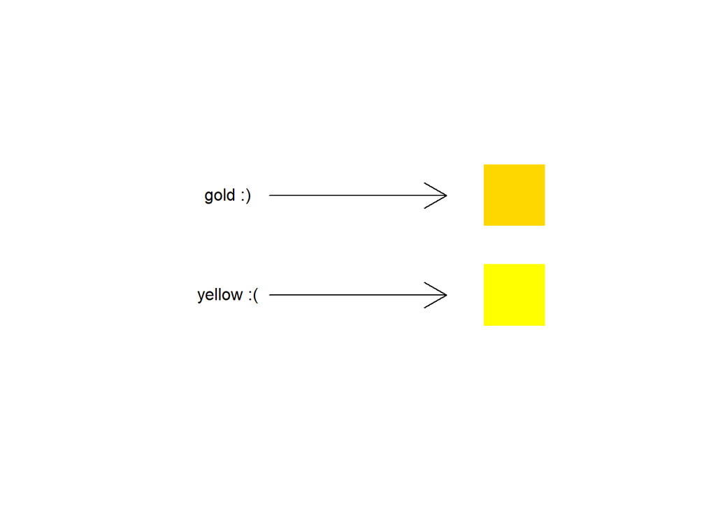

6. Make sure you read the hints in the HWs. They will guide you on some things and they will make your life easier.
7. When running regressions in R, try your best to use code like `lm(y ~ x, data = df)` instead of `lm(df$y ~ df~x)`. There are a few reasons why, but suppose you want to run one regression with data before 2010 and one regression with data after. There would be two ways to run the regressions:

```r
lim <- df$year < 2010

reg_before <- lm(y ~ x, data = df[lim,])
reg_after <- lm(y ~ x, data = df[!lim,])

reg_before <- lm(df$y[lim] ~ df$x[lim])
reg_after <- lm(df$y[!lim] ~ df$x[!lim])
```

From here, it should be obvious that the first way is better than the second way. Further, it should be obvious that this second way gets increasingly worse as you add variables. Lazy coding is the best coding - words to live by.

8. From now on, we are going to be submitting both .html and .Rmd files for homework submissions. To make this easier on me, please read data straight from github. For example: `read.csv("https://alexcardazzi.github.io/teaching/econ-593e/example_data.csv")`. This way, I can leave comments right in your .Rmd file and give better feedback.
9. The `table()` function is a very important and powerful function. When only a single vector is given, `table()` will take all of the unique values from this vector and count the number of occurances. Suppose you have a vector `x <- c(1, 3, 6, 2, 6, 1, 1, 3, 4)`. Using `table(x)` will yield the counts of each of the numbers as below:

```
##
## 1 2 3 4 6
## 3 1 2 1 2
```

Here, we can see that `1` occurs three times, etc. When your data get larger, this is really helpful to understand what it all looks like.

A second use of `table()` would be to feed it *two* vectors. This will make a cross tabulation. Below is an example:

```r
country <- c("A", "A", "A", "A", "B", "A", "B", "B", "B", "A", "B", "B", "A", "A", "B", "B")
treatment <- c(1, 1, 1, 1, 1, 1, 0, 0, 0, 0, 0, 0, 0, 0, 0, 0)
table(country, treatment)
```

```
##        treatment
## country 0 1
##       A 3 5
##       B 7 1
```

Now, you can tell how many times country A was treated vs not treated, and the same for B. It is a very helpful way to summarise data.

A final thing to note about table is that sometimes, in the real world, we have missing data. `table()` will ignore misssing values unless you tell it not to. the argument we need is `useNA = "always"`. Check out the below examples:

```r
x <- c(1, 2, 3, 1, 1, 2, 1, 1, 3, 2)
table(x, useNA = "always")
```

```
## x
##    1    2    3 <NA>
##    5    3    2    0
```

```r
x <- c(1, 2, NA, NA, 1, NA, 1, 1, 3, 2)
table(x, useNA = "always")
```

```
## x
##    1    2    3 <NA>
##    4    2    1    3
```

10. Subsetting data is one of the most common things you will have to do in R. It is hardly the case that you will be using an entire dataset all the time. This is something you will have to master. Subsetting in R can be done easily by using logical vectors. Suppose we have a dataset called `places` that contains countries and their GDPs as below:

```r
data.frame(country = c("italy", "american", "brazil", "japan", "england", "india", "taiwan", "portugal"),
           gdp = c(10, 14, 18, NA, NA, 18, 12, 9),
           cont = c("eu", "na", "sa", "as", "eu", "as", "as", "eu")) -> places
```

Suppose we want to only look at european counties and drop everything else. Obviously, this dataset is small, so we can visually see what all exists. If we need to check it out, though, we can use `table()` as outlined before. Let's say we already know everything about the data, and we want to subset now. This is relatively easy. We would just ask which elements in `places$cont` are equal to `"eu"`. This is done by: `places$cont == "eu"`. This will return a vector of `TRUE` and `FALSE` values that we can use to tell R which rows we want to keep. We can then use the line `places[places$cont == "eu",]`. Notice how I used a comma after the `"eu"`. This is to keep all the columns in the dataset. Then, if you want to overwrite `places`, you can do so by `places <- places[places$cont == "eu",]`.

Now suppose we want to remove countries with 10 or less GDP from the dataset instead of just keeping european countries. We can use very similar logic. We can do something like `places$gdp > 10` as our limit, right? Not quite. If we run this line, we get: FALSE, TRUE, TRUE, NA, NA, TRUE, TRUE, FALSE. Clearly, this does what we want by returning `FALSE` for GDPs less than or equal to 10. However, there are two NA values that we will need to do something about. For example:

```r
places1 <- places[places$gdp > 10,]
places1
```

```
##       country gdp cont
## 2    american  14   na
## 3      brazil  18   sa
## NA       <NA>  NA <NA>
## NA.1     <NA>  NA <NA>
## 6       india  18   as
## 7      taiwan  12   as
```

Notice how we have replaced Japan and England with two rows of complete NA values. We need to remove these. Again, we are going to go back to our logical vectors and ask R which have GDP greater than 10 **AND** GDP not `NA`. We can test if something is an `NA` value by using the function `is.na()`. In order to get NOT `NA`, we use `!is.na()`. Putting them together with the AND operator: `places$gdp > 10 & !is.na(places$gdp)`.

```r
places2 <- places[places$gdp > 10 & !is.na(places$gdp),]
places2
```

```
##    country gdp cont
## 2 american  14   na
## 3   brazil  18   sa
## 6    india  18   as
## 7   taiwan  12   as
```